# Pemodelan ARIMA Data Curah Hujan Harian

Praktikum MPDW

Silvia Indriyani (X1004261007)

1 Oktober 2026

# 1 Data

Data berupa curah hujan harian (mm) dari 1 Januari 1969 sampai 31 Desember 1970 (**730 amatan**, memenuhi syarat minimal 500 amatan).

```r
d <- read.csv("data_time_series_curah_hujan.csv")
d$Tanggal <- as.Date(d$Tanggal)
x <- d$Curah_Hujan_mm
cat("Jumlah amatan:", length(x), "| NA:", sum(is.na(x)), "| Proporsi hari tanpa hujan:", round(mean(x == 0), 3))
```

```
## Jumlah amatan: 730 | NA: 0 | Proporsi hari tanpa hujan: 0.459
```

```r
summary(x)
```

```
##    Min. 1st Qu.  Median    Mean 3rd Qu.    Max.
##    0.00    0.00    1.00   10.74   12.00  549.00
```

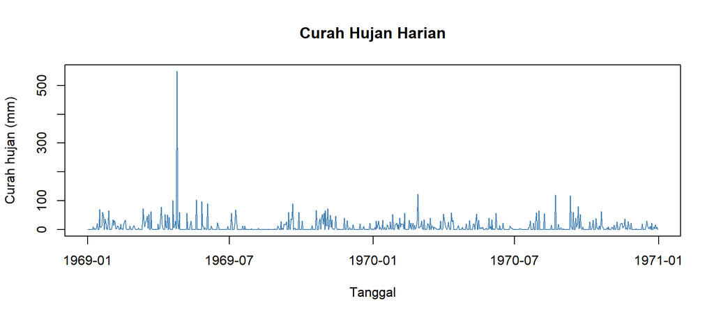

```r
plot(d$Tanggal, x, type = "l", col = "steelblue", xlab = "Tanggal", ylab = "Curah hujan (mm)",
     main = "Curah Hujan Harian")
```

# 2 Tahap 1: Pembagian Data Train dan Test

Plot menunjukkan tidak ada tren yang jelas dan pola relatif homogen sepanjang waktu, sehingga data dibagi **80% train (584 amatan)** dan **20% test (146 amatan)** secara berurutan.

```r
n <- length(x); ntr <- floor(0.8 * n)
train <- x[1:ntr]; test <- x[(ntr + 1):n]
tgl_tr <- d$Tanggal[1:ntr]; tgl_te <- d$Tanggal[(ntr + 1):n]
cat("Train:", ntr, "(", format(min(tgl_tr)), "s/d", format(max(tgl_tr)), ")\n")
```

```
## Train: 584 ( 1969-01-01 s/d 1970-08-07 )
```

```r
cat("Test :", length(test), "(", format(min(tgl_te)), "s/d", format(max(tgl_te)), ")")
```

```
## Test : 146 ( 1970-08-08 s/d 1970-12-31 )
```

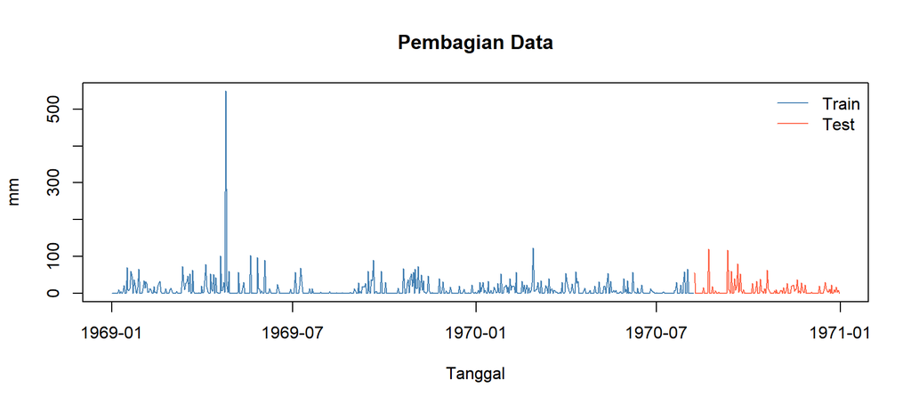

```r
plot(d$Tanggal, x, type = "n", xlab = "Tanggal", ylab = "mm", main = "Pembagian Data")
lines(tgl_tr, train, col = "steelblue"); lines(tgl_te, test, col = "tomato")
legend("topright", c("Train", "Test"), col = c("steelblue", "tomato"), lty = 1, bty = "n")
```

# 3 Tahap 2: Uji Stasioneritas Data Train

## 3.1 Stasioneritas dalam rataan

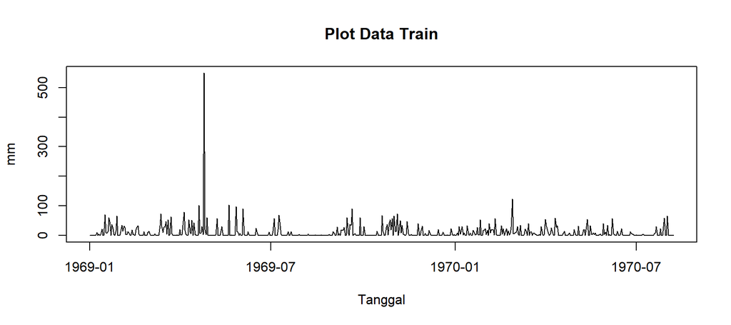

```r
plot(tgl_tr, train, type = "l", xlab = "Tanggal", ylab = "mm", main = "Plot Data Train")
```

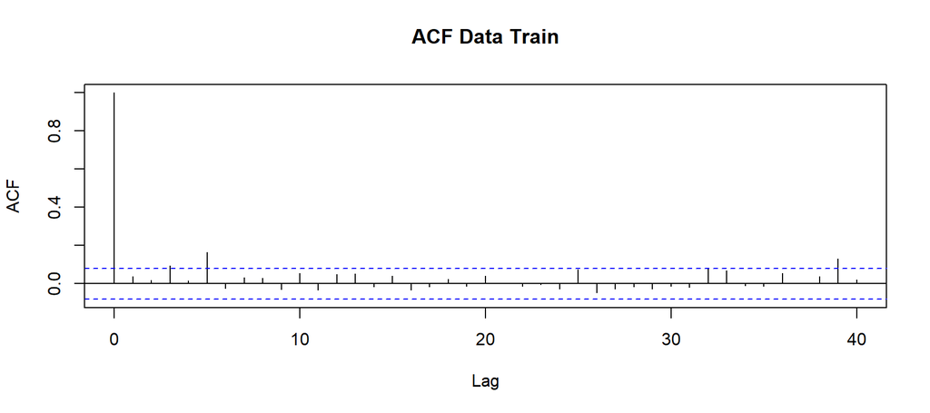

```r
acf(train, lag.max = 40, main = "ACF Data Train")
```

```r
adf.test(train)
```

```
##
##  Augmented Dickey-Fuller Test
##
## data:  train
## Dickey-Fuller = -7.3058, Lag order = 8, p-value = 0.01
## alternative hypothesis: stationary
```

```r
kpss.test(train)
```

```
##
##  KPSS Test for Level Stationarity
##
## data:  train
## KPSS Level = 0.32747, Truncation lag parameter = 6, p-value = 0.1
```

Uji ADF: H0 = data tidak stasioner. Jika p-value < 0.05 maka H0 ditolak (stasioner dalam rataan). Uji KPSS sebagai pembanding (H0 = stasioner).

**Interpretasi:** ADF menghasilkan p-value 0.01 (< 0.05) sehingga H0 ditolak, dan KPSS (p > 0.05) tidak menolak H0. ACF turun cepat mendekati nol (tidak meluruh lambat). Jadi data train sudah **stasioner dalam rataan**, tidak perlu diferensiasi.

## 3.2 Stasioneritas dalam ragam (Box-Cox)

Data memuat nilai 0 (hari tanpa hujan), padahal Box-Cox mensyaratkan data positif. Maka data digeser +1 (`y + 1`) sebelum Box-Cox.

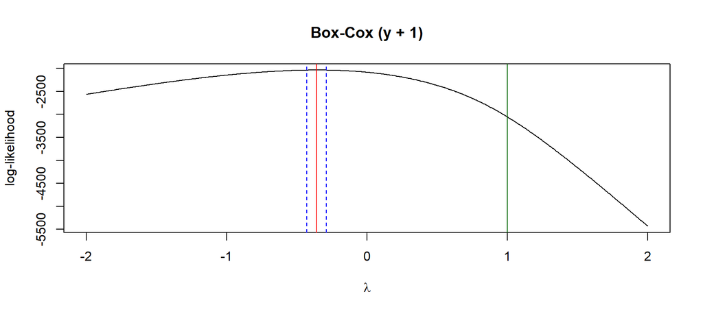

```r
y1 <- train + 1
bc <- boxcox(lm(y1 ~ 1), lambda = seq(-2, 2, 0.01), plotit = FALSE)
lam <- bc$x[which.max(bc$y)]
ci  <- range(bc$x[bc$y > max(bc$y) - qchisq(0.95, 1) / 2])
plot(bc$x, bc$y, type = "l", xlab = expression(lambda), ylab = "log-likelihood", main = "Box-Cox (y + 1)")
abline(v = c(lam, ci), lty = c(1, 2, 2), col = c("red", "blue", "blue")); abline(v = 1, col = "darkgreen")
```

```r
cat("Lambda optimum:", lam, "\nSelang kepercayaan 95%: [", ci[1], ",", ci[2], "]\nMengandung 1?", ci[1] <= 1 & 1 <= ci[2])
```

```
## Lambda optimum: -0.36
## Selang kepercayaan 95%: [ -0.43 , -0.29 ]
## Mengandung 1? FALSE
```

**Interpretasi:** lambda optimum = -0.36 dengan selang kepercayaan 95% [-0.43, -0.29]. Selang tidak memuat 1, maka data **belum stasioner dalam ragam** (ragam besar pada hari hujan ekstrem, maksimum 549 mm) dan perlu ditransformasi.

# 4 Tahap 3: Penanganan Ketidakstasioneran

Selang kepercayaan lambda tidak memuat 1 berarti ragam tidak stasioner, sehingga data **ditransformasi**. Karena lambda mendekati nilai di bawah nol, dipakai transformasi Box-Cox dengan lambda optimum. Untuk rataan, diferensiasi hanya dilakukan jika ADF tidak menolak H0.

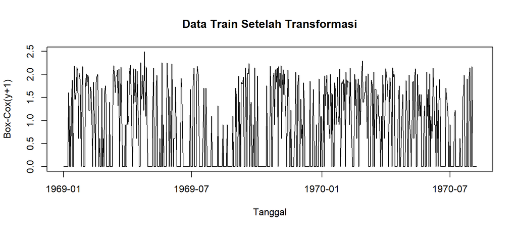

```r
lam_use <- lam
tf  <- function(v) ((v + 1)^lam_use - 1) / lam_use
itf <- function(z) (z * lam_use + 1)^(1 / lam_use) - 1
ztr <- tf(train)
plot(tgl_tr, ztr, type = "l", xlab = "Tanggal", ylab = "Box-Cox(y+1)", main = "Data Train Setelah Transformasi")
```

```r
adf.test(ztr)
```

```
##
##  Augmented Dickey-Fuller Test
##
## data:  ztr
## Dickey-Fuller = -5.6596, Lag order = 8, p-value = 0.01
## alternative hypothesis: stationary
```

```r
kpss.test(ztr)
```

```
##
##  KPSS Test for Level Stationarity
##
## data:  ztr
## KPSS Level = 0.24113, Truncation lag parameter = 6, p-value = 0.1
```

```r
p_adf <- adf.test(ztr)$p.value
d_ord <- 0
if (p_adf > 0.05) { d_ord <- 1; print(adf.test(diff(ztr))) }
cat("Orde diferensiasi (d) yang digunakan:", d_ord)
```

```
## Orde diferensiasi (d) yang digunakan: 0
```

```r
zs <- if (d_ord == 1) diff(ztr) else ztr
```

**Interpretasi:** setelah transformasi, data tetap stasioner dalam rataan (ADF p = 0.01, KPSS p > 0.05) sehingga d = 0.

# 5 Tahap 4: Identifikasi Model Potensial

## 5.1 ACF dan PACF

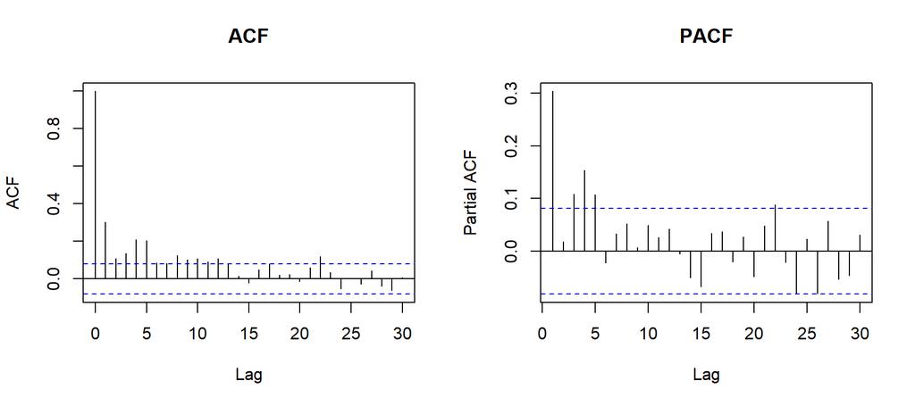

```r
par(mfrow = c(1, 2)); acf(zs, lag.max = 30, main = "ACF"); pacf(zs, lag.max = 30, main = "PACF"); par(mfrow = c(1, 1))
```

## 5.2 EACF

Paket `TSA` tidak tersedia di semua lingkungan, sehingga fungsi EACF ditulis manual (algoritma Tsay & Tiao, sama dengan `TSA::eacf`). Simbol `o` berarti tidak signifikan dan `x` berarti signifikan.

```r
eacf2 <- function(z, ar.max = 7, ma.max = 13) {
  z <- z - mean(z); n <- length(z)
  lag <- function(v, k) if (k == 0) v else c(rep(0, k), v[1:(length(v) - k)])
  ee <- matrix(NA, ar.max + 1, ma.max + 1)
  for (p in 0:ar.max) for (q in 0:ma.max) {
    r <- z
    if (p > 0) { X <- sapply(1:p, function(k) lag(z, k)); b <- coef(lm(z ~ X - 1)); r <- z - X %*% b }
    r <- as.numeric(r)
    if (q > 0) for (j in 1:q) {
      Xr <- cbind(if (p > 0) X, sapply(1:j, function(k) lag(r, k)))
      if (is.null(dim(Xr))) Xr <- matrix(Xr, ncol = 1)
      b <- coef(lm(z ~ Xr - 1))
      r <- as.numeric(z - Xr %*% b)
    }
    ee[p + 1, q + 1] <- acf(r, lag.max = q + 1, plot = FALSE)$acf[q + 2]
  }
  sym <- ifelse(abs(ee) > 2 / sqrt(n - outer(0:ar.max, 0:ma.max, "+")), "x", "o")
  dimnames(sym) <- list(paste0("AR", 0:ar.max), paste0("MA", 0:ma.max))
  noquote(sym)
}
eacf2(zs)
```

```
##     MA0 MA1 MA2 MA3 MA4 MA5 MA6 MA7 MA8 MA9 MA10 MA11 MA12 MA13
## AR0 x   o   x   x   x   o   o   o   o   x   o    o    o    o
## AR1 o   o   o   o   o   o   o   o   o   o   o    o    o    o
## AR2 o   o   o   o   x   o   o   o   o   o   o    o    o    o
## AR3 o   o   o   o   o   o   o   o   o   o   o    o    o    o
## AR4 o   o   o   o   o   o   o   o   o   o   o    o    o    o
## AR5 o   o   o   o   o   o   o   o   o   o   o    o    o    o
## AR6 o   o   o   o   o   o   o   o   o   o   o    o    o    o
## AR7 o   o   o   o   o   o   o   o   o   o   o    o    o    o
```

**Interpretasi:** ACF meluruh perlahan (masih di atas batas signifikansi sampai lag 12) dan PACF signifikan pada lag 1, 3, 4, dan 5 lalu terputus, yang mengarah ke komponen AR (hingga orde 5) atau model campuran ARMA. EACF menunjukkan segitiga `o` mulai dari AR1/MA0 pada baris AR1 dan seterusnya, dengan `x` hanya pada baris AR0 (dan satu pada AR2/MA4), sehingga ARMA(1,q) kecil menjadi kandidat utama. Kandidat: ARMA(1,0), (0,1), (1,1), (2,1), (1,2), AR(5), MA(5), AR(3), dan white noise sebagai pembanding.

## 5.3 Kandidat model

Kandidat diambil dari pola ACF/PACF/EACF (termasuk model sederhana di sekitarnya), dengan orde `d` sesuai tahap 3.

```r
cand <- list(c(0,0,0), c(1,0,0), c(0,0,1), c(1,0,1), c(5,0,0), c(0,0,5), c(3,0,0), c(2,0,1), c(1,0,2))
cand <- lapply(cand, function(o) c(o[1], d_ord, o[3]))
fits <- list()
for (o in cand) {
  nm <- sprintf("ARIMA(%d,%d,%d)", o[1], o[2], o[3])
  fits[[nm]] <- tryCatch(Arima(ztr, order = o, include.mean = (d_ord == 0), method = "ML"), error = function(e) NULL)
}
fits <- Filter(Negate(is.null), fits)
```

# 6 Tahap 5: Signifikansi Parameter dan AIC

```r
sig_all <- function(f) { ct <- coeftest(f); all(ct[rownames(ct) != "intercept", 4] < 0.05) }
tab <- data.frame(Model = names(fits),
                  AIC = sapply(fits, AIC), BIC = sapply(fits, BIC),
                  Semua_Signifikan = sapply(fits, sig_all), row.names = NULL)
tab <- tab[order(tab$AIC), ]; tab
```

|  | Model | AIC | BIC | Semua_Signifikan |
| --- | --- | --- | --- | --- |
| 5 | ARIMA(5,0,0) | 1385.532 | 1416.121 | FALSE |
| 9 | ARIMA(1,0,2) | 1389.387 | 1411.236 | TRUE |
| 6 | ARIMA(0,0,5) | 1391.365 | 1421.954 | FALSE |
| 8 | ARIMA(2,0,1) | 1392.021 | 1413.871 | TRUE |
| 4 | ARIMA(1,0,1) | 1399.270 | 1416.749 | TRUE |
| 7 | ARIMA(3,0,0) | 1402.785 | 1424.634 | FALSE |
| 2 | ARIMA(1,0,0) | 1405.988 | 1419.098 | TRUE |
| 3 | ARIMA(0,0,1) | 1410.390 | 1423.500 | TRUE |
| 1 | ARIMA(0,0,0) | 1460.636 | 1469.376 | TRUE |

```r
for (nm in names(fits)) { cat("\n====", nm, "====\n"); print(coeftest(fits[[nm]])) }
```

```
##
## ==== ARIMA(0,0,0) ====
##
## z test of coefficients:
##
##           Estimate Std. Error z value  Pr(>|z|)
## intercept 0.825673   0.034848  23.694 < 2.2e-16 ***
## ---
## Signif. codes:  0 '***' 0.001 '**' 0.01 '*' 0.05 '.' 0.1 ' ' 1
##
##
## ==== ARIMA(1,0,0) ====
##
## z test of coefficients:
##
##           Estimate Std. Error z value  Pr(>|z|)
## ar1       0.304269   0.039430  7.7166 1.195e-14 ***
## intercept 0.824434   0.047677 17.2919 < 2.2e-16 ***
## ---
## Signif. codes:  0 '***' 0.001 '**' 0.01 '*' 0.05 '.' 0.1 ' ' 1
##
##
## ==== ARIMA(0,0,1) ====
##
## z test of coefficients:
##
##           Estimate Std. Error z value  Pr(>|z|)
## ma1       0.286251   0.037514  7.6306 2.337e-14 ***
## intercept 0.825110   0.042843 19.2591 < 2.2e-16 ***
## ---
## Signif. codes:  0 '***' 0.001 '**' 0.01 '*' 0.05 '.' 0.1 ' ' 1
##
##
## ==== ARIMA(1,0,1) ====
##
## z test of coefficients:
##
##            Estimate Std. Error z value  Pr(>|z|)
## ar1        0.887391   0.048941 18.1320 < 2.2e-16 ***
## ma1       -0.726819   0.074736 -9.7251 < 2.2e-16 ***
```

[output cut: 57 more lines]

```
## ---
## Signif. codes:  0 '***' 0.001 '**' 0.01 '*' 0.05 '.' 0.1 ' ' 1
##
##
## ==== ARIMA(1,0,2) ====
##
## z test of coefficients:
##
##            Estimate Std. Error  z value  Pr(>|z|)
## ar1        0.932933   0.033058  28.2214 < 2.2e-16 ***
## ma1       -0.658185   0.054328 -12.1151 < 2.2e-16 ***
## ma2       -0.160265   0.046156  -3.4722 0.0005162 ***
## intercept  0.811248   0.087278   9.2950 < 2.2e-16 ***
## ---
## Signif. codes:  0 '***' 0.001 '**' 0.01 '*' 0.05 '.' 0.1 ' ' 1
```

```r
ok <- tab[tab$Semua_Signifikan, ]
best_name <- if (nrow(ok) > 0) ok$Model[which.min(ok$AIC)] else tab$Model[1]
best <- fits[[best_name]]
cat("Model terpilih:", best_name, "(parameter signifikan dengan AIC terkecil)")
```

```
## Model terpilih: ARIMA(1,0,2) (parameter signifikan dengan AIC terkecil)
```

**Interpretasi:** ARIMA(5,0,0) memiliki AIC terkecil (1385.5) tetapi ar2 dan ar3 tidak signifikan. Di antara model yang seluruh parameternya signifikan, **ARIMA(1,0,2)** punya AIC terkecil (1389.4) dan BIC terkecil di antara seluruh kandidat (1411.2), sehingga dipilih.

# 7 Tahap 6: Analisis Sisaan

```r
checkresiduals(best, plot = FALSE)
```

```
##
##  Ljung-Box test
##
## data:  Residuals from ARIMA(1,0,2) with non-zero mean
## Q* = 12.601, df = 7, p-value = 0.08244
##
## Model df: 3.   Total lags used: 10
```

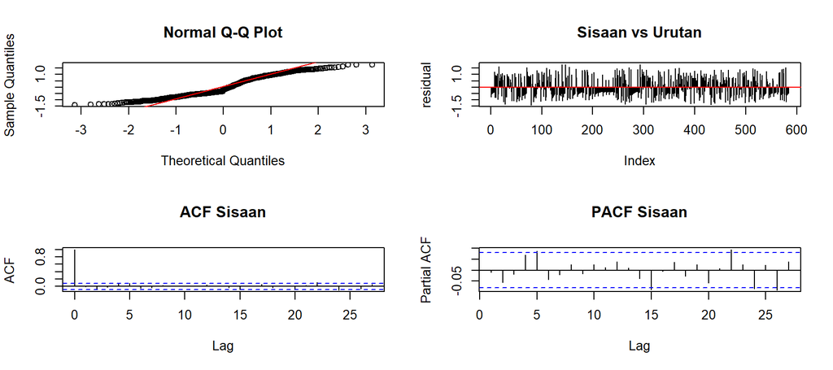

```r
r <- as.numeric(residuals(best))
par(mfrow = c(2, 2))
qqnorm(r); qqline(r, col = "red")
plot(r, type = "h", main = "Sisaan vs Urutan", ylab = "residual"); abline(h = 0, col = "red")
acf(r, main = "ACF Sisaan"); pacf(r, main = "PACF Sisaan")
```

```r
par(mfrow = c(1, 1))
```

```r
cat("Uji Normalitas (Jarque-Bera & Kolmogorov-Smirnov), H0: sisaan normal\n")
```

```
## Uji Normalitas (Jarque-Bera & Kolmogorov-Smirnov), H0: sisaan normal
```

```r
print(jarque.bera.test(r)); print(ks.test(scale(r), "pnorm"))
```

```
##
##  Jarque Bera Test
##
## data:  r
## X-squared = 40.37, df = 2, p-value = 1.713e-09
```

```
##
##  Asymptotic one-sample Kolmogorov-Smirnov test
##
## data:  scale(r)
## D = 0.1554, p-value = 1.126e-12
## alternative hypothesis: two-sided
```

```r
cat("\nUji Autokorelasi (Ljung-Box), H0: tidak ada autokorelasi\n")
```

```
##
## Uji Autokorelasi (Ljung-Box), H0: tidak ada autokorelasi
```

```r
print(Box.test(r, lag = 20, type = "Ljung-Box", fitdf = length(coef(best)) - (d_ord == 0)))
```

```
##
##  Box-Ljung test
##
## data:  r
## X-squared = 23.44, df = 17, p-value = 0.1355
```

```r
cat("\nUji Homogenitas Ragam (Ljung-Box pada sisaan kuadrat / efek ARCH), H0: ragam homogen\n")
```

```
##
## Uji Homogenitas Ragam (Ljung-Box pada sisaan kuadrat / efek ARCH), H0: ragam homogen
```

```r
print(Box.test(r^2, lag = 20, type = "Ljung-Box"))
```

```
##
##  Box-Ljung test
##
## data:  r^2
## X-squared = 33.576, df = 20, p-value = 0.02914
```

```r
cat("\nUji Nilai Tengah Sisaan (t-test), H0: rataan = 0\n")
```

```
##
## Uji Nilai Tengah Sisaan (t-test), H0: rataan = 0
```

```r
print(t.test(r, mu = 0))
```

```
##
##  One Sample t-test
##
## data:  r
## t = 0.11335, df = 583, p-value = 0.9098
## alternative hypothesis: true mean is not equal to 0
## 95 percent confidence interval:
##  -0.06040327  0.06780217
## sample estimates:
##  mean of x
## 0.00369945
```

**Interpretasi:** (1) Rataan sisaan = 0 (p = 0.91): terpenuhi. (2) Tidak ada autokorelasi (Ljung-Box p = 0.136 > 0.05): terpenuhi. (3) Sisaan **tidak normal** (Jarque-Bera dan KS p < 0.05), akibat hari hujan ekstrem; hal ini wajar untuk data curah hujan dan tidak mengubah kelayakan estimasi titik. (4) Ragam sisaan **tidak homogen** (Ljung-Box pada sisaan kuadrat p = 0.029 < 0.05, indikasi efek ARCH), sehingga selang prediksi perlu ditafsirkan hati-hati; model GARCH dapat dipertimbangkan sebagai pengembangan.

# 8 Tahap 7: Overfitting

Model terpilih dinaikkan ordenya satu tingkat pada AR dan MA, lalu dibandingkan AIC dan signifikansi parameter tambahan.

```r
o <- arimaorder(best); p0 <- o[1]; q0 <- o[3]
ov <- list(c(p0 + 1, d_ord, q0), c(p0, d_ord, q0 + 1))
ovfit <- list(); ovfit[[best_name]] <- best
for (oo in ov) { nm <- sprintf("ARIMA(%d,%d,%d)", oo[1], oo[2], oo[3])
  ovfit[[nm]] <- tryCatch(Arima(ztr, order = oo, include.mean = (d_ord == 0), method = "ML"), error = function(e) NULL) }
ovfit <- Filter(Negate(is.null), ovfit)
data.frame(Model = names(ovfit), AIC = sapply(ovfit, AIC), Semua_Signifikan = sapply(ovfit, sig_all), row.names = NULL)
```

| Model | AIC | Semua_Signifikan |
| --- | --- | --- |
| ARIMA(1,0,2) | 1389.387 | TRUE |
| ARIMA(2,0,2) | 1390.168 | FALSE |
| ARIMA(1,0,3) | 1388.841 | FALSE |

```r
for (nm in names(ovfit)[-1]) { cat("\n====", nm, "====\n"); print(coeftest(ovfit[[nm]])) }
```

```
##
## ==== ARIMA(2,0,2) ====
##
## z test of coefficients:
##
##            Estimate Std. Error z value  Pr(>|z|)
## ar1        0.698304   0.219169  3.1861  0.001442 **
## ar2        0.211302   0.193416  1.0925  0.274625
## ma1       -0.430541   0.210748 -2.0429  0.041061 *
## ma2       -0.327282   0.151063 -2.1665  0.030271 *
## intercept  0.811326   0.086359  9.3948 < 2.2e-16 ***
## ---
## Signif. codes:  0 '***' 0.001 '**' 0.01 '*' 0.05 '.' 0.1 ' ' 1
##
##
## ==== ARIMA(1,0,3) ====
##
## z test of coefficients:
##
##            Estimate Std. Error  z value  Pr(>|z|)
## ar1        0.912147   0.040800  22.3565 < 2.2e-16 ***
## ma1       -0.656563   0.056428 -11.6355 < 2.2e-16 ***
## ma2       -0.187087   0.047695  -3.9226  8.76e-05 ***
## ma3        0.073477   0.045208   1.6253    0.1041
## intercept  0.811273   0.084370   9.6156 < 2.2e-16 ***
## ---
## Signif. codes:  0 '***' 0.001 '**' 0.01 '*' 0.05 '.' 0.1 ' ' 1
```

**Interpretasi:** pada ARIMA(2,0,2) parameter ar2 tidak signifikan, dan pada ARIMA(1,0,3) parameter ma3 tidak signifikan (p = 0.104). Selisih AIC dengan model awal sangat kecil (< 1), jadi penambahan parameter tidak memberi perbaikan berarti. **ARIMA(1,0,2) tetap dipakai**.

# 9 Tahap 8: Peramalan

Peramalan dilakukan pada skala transformasi untuk 146 hari data test, kemudian dikembalikan ke skala asli (mm) dengan transformasi balik.

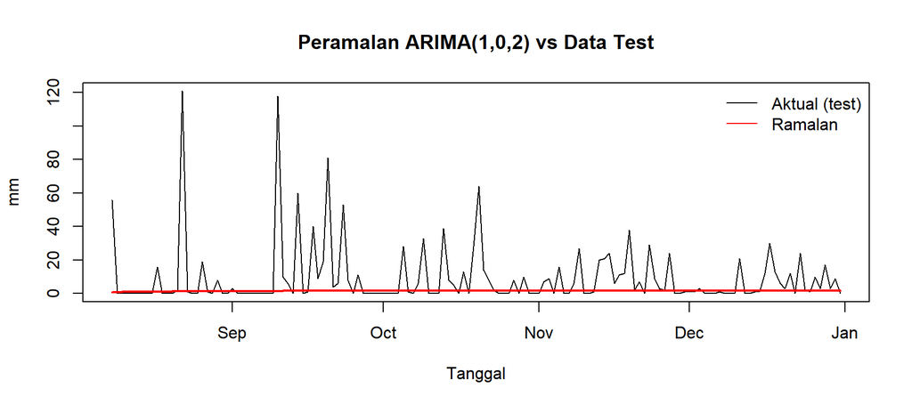

```r
h <- length(test)
fc <- forecast(best, h = h)
pred <- pmax(itf(as.numeric(fc$mean)), 0)
lo <- pmax(itf(as.numeric(fc$lower[, 2])), 0); hi <- itf(as.numeric(fc$upper[, 2]))
plot(tgl_te, test, type = "l", col = "black", ylim = c(0, max(test, na.rm = TRUE)),
     xlab = "Tanggal", ylab = "mm", main = paste("Peramalan", best_name, "vs Data Test"))
lines(tgl_te, pred, col = "red", lwd = 2)
legend("topright", c("Aktual (test)", "Ramalan"), col = c("black", "red"), lty = 1, bty = "n")
```

```r
rmse <- sqrt(mean((test - pred)^2)); mae <- mean(abs(test - pred))
rmse_naif <- sqrt(mean((test - mean(train))^2)); mae_naif <- mean(abs(test - mean(train)))
data.frame(Ukuran = c("RMSE", "MAE"), ARIMA = round(c(rmse, mae), 3),
           Pembanding_rataan_train = round(c(rmse_naif, mae_naif), 3))
```

| Ukuran | ARIMA | Pembanding_rataan_train |
| --- | --- | --- |
| RMSE | 20.575 | 19.084 |
| MAE | 9.282 | 12.338 |

```r
head(data.frame(Tanggal = tgl_te, Aktual = test, Ramalan = round(pred, 2)), 10)
```

| Tanggal | Aktual | Ramalan |
| --- | --- | --- |
| 1970-08-08 | 56 | 0.64 |
| 1970-08-09 | 0 | 0.85 |
| 1970-08-10 | 0 | 0.89 |
| 1970-08-11 | 0 | 0.93 |
| 1970-08-12 | 0 | 0.97 |
| 1970-08-13 | 0 | 1.01 |
| 1970-08-14 | 0 | 1.04 |
| 1970-08-15 | 0 | 1.07 |
| 1970-08-16 | 0 | 1.10 |
| 1970-08-17 | 16 | 1.13 |

# 10 Kesimpulan

1. Data: 730 amatan harian, dibagi 584 train dan 146 test (80:20).
2. Data train stasioner dalam rataan (ADF p = 0.01) tetapi tidak stasioner dalam ragam (selang lambda [-0.43, -0.29] tidak memuat 1), sehingga ditransformasi Box-Cox (lambda = -0.36) pada `y + 1`, tanpa diferensiasi (d = 0).
3. Model terbaik: **ARIMA(1,0,2)** (seluruh parameter signifikan, AIC = 1389.4); overfitting ARIMA(2,0,2) dan ARIMA(1,0,3) tidak memperbaiki model.
4. Sisaan: rataan nol dan tidak berautokorelasi, tetapi tidak normal dan ragamnya tidak homogen (indikasi efek ARCH).
5. Peramalan 146 hari: MAE = 9.28 mm, RMSE = 20.58 mm. Kemampuan ARIMA terbatas karena data curah hujan harian bersifat sangat acak dan penuh nilai nol.